# Simulation Experiments

Rafael Alcantara

2025-01-02

## DGP

Features $X,W$, treatment variable $Z$ and outcome $Y$ are generated as:

$$\begin{equation}
\begin{split}
X &\sim \mathbb{N}(0, 1)\\
Z &= \mathbb{1}(X \geq 0)\\
W &\sim \mathbb{N}(\rho X, \sqrt{1-\rho^2})\\
\rho &\in \{0.5,0.9\}\\
Y &\sim \mathbb{N}(\mu(X,W) + \tau(X,W)Z, 1).
\end{split}
\end{equation}$$

Each DGP is defined by a tuple ${K_1,K_2,\rho}$. Parameter $K_1$ controls how fast $\mu_{0,x}(X)$ moves away from $\mu_{0,x}(X=0)$. This is relevant particularly for S-BART and T-BART, since these estimators provide no control over how points far from the cutoff affect predictions at that point. Consider a split in $W$ such that points with both $X$ close to or far from $X=c$ are included in the same node. If $E[Y \mid X,W]$ differs substantially between these two regions of the support of $X$, such nodes will provide very poor approximations for $E[Y \mid X=c,W,Z=1]-E[Y \mid X=c,W,Z=0]$, compromising the performance of the unmodified BART estimators. We avoid this issue by significantly increasing the likelihood that these nodes will split in $X$ and imposing that they must be split until all nodes which contain the cutoff region feature only few points with $X$ outside our proposed window. The polynomial estimator avoids this issue by discarding points outside their proposed window. Therefore, parameter $K_1$ allows us to investigate how much this should be an issue for S-BART and T-BART.

Parameter $K_2$ controls the variability due to $W$ in $\mu$ compared to $\tau$. Because RDD treatment effects are only identified at $X=c$, the variability in $W$ in each function is what matters most to determine how hard it is to learn the treatment effect function. In particular, we expect larger values of $K_2$ to make the problem harder. The specific grid for this parameter was chosen such that $sd(\mu(X=c,W))$ is, respectively, one and three times greater than $sd(\tau(X=c,W))$.

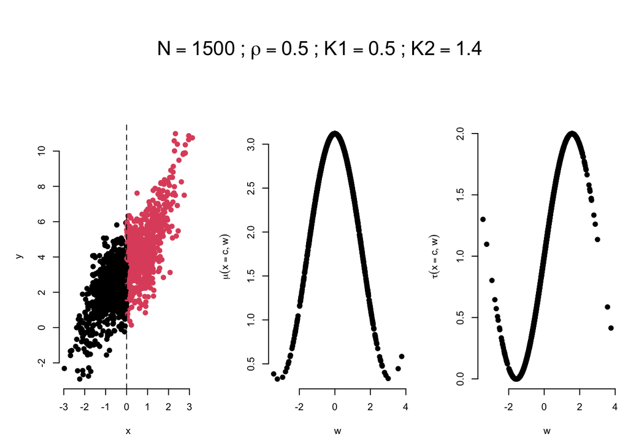

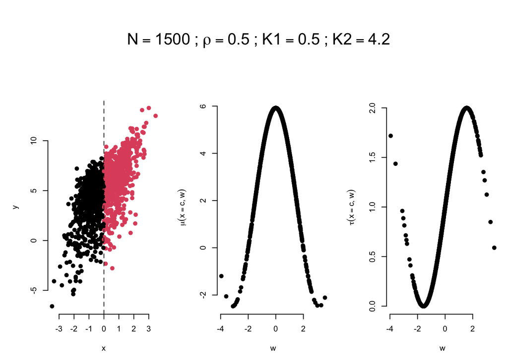

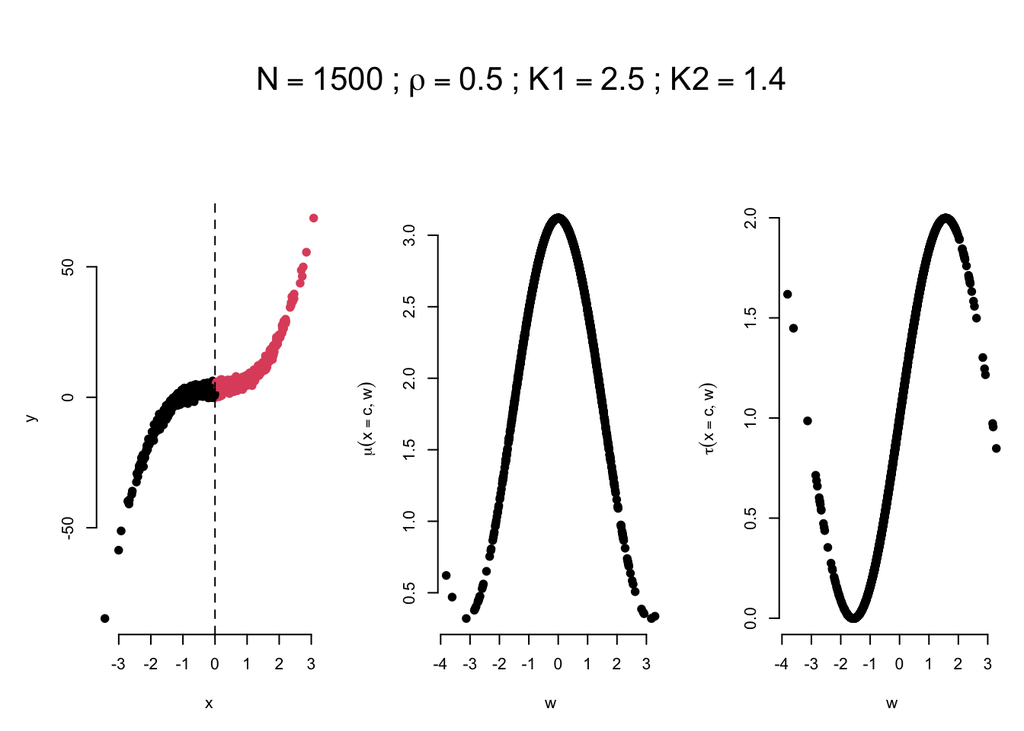

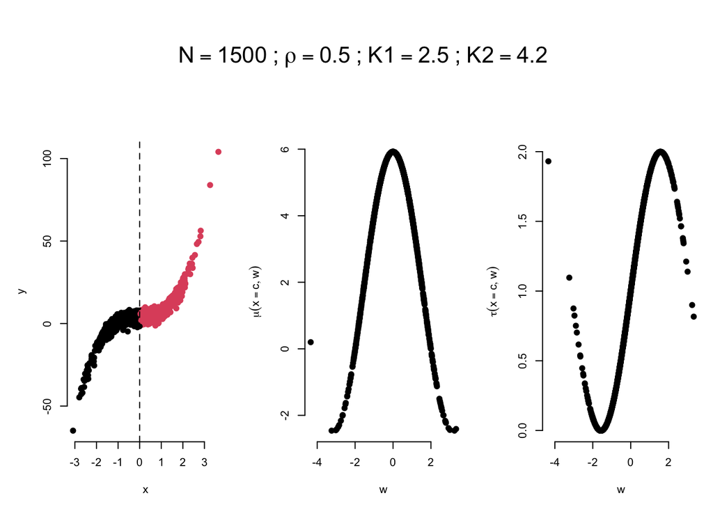

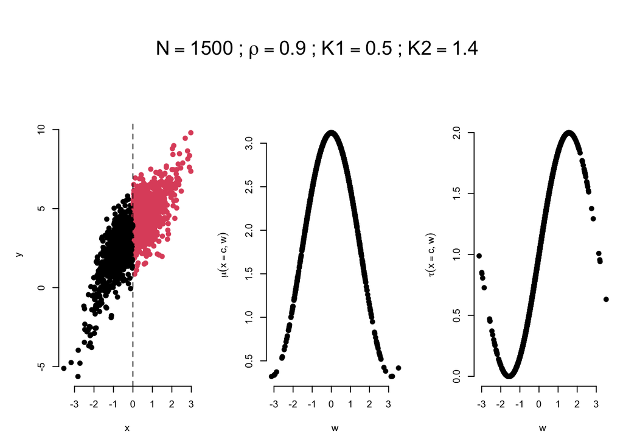

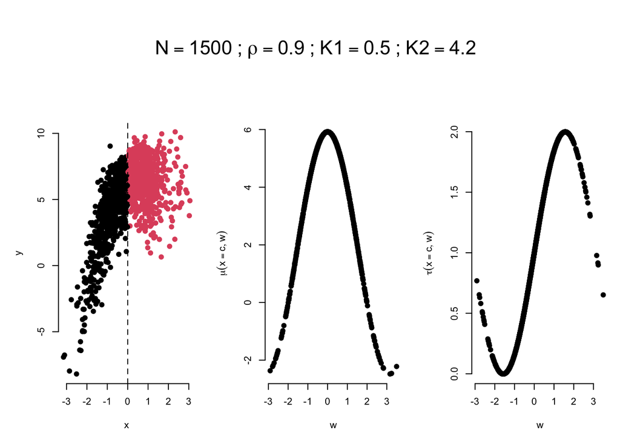

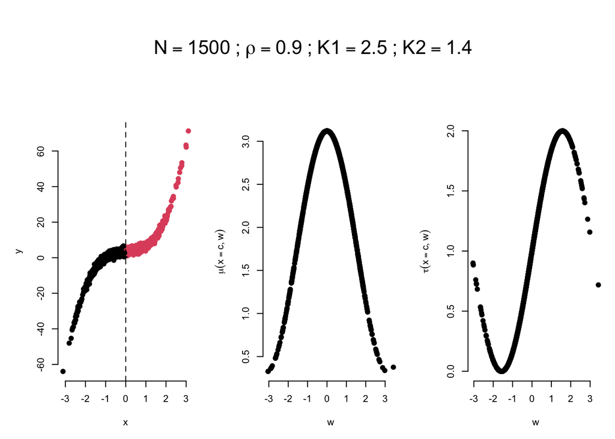

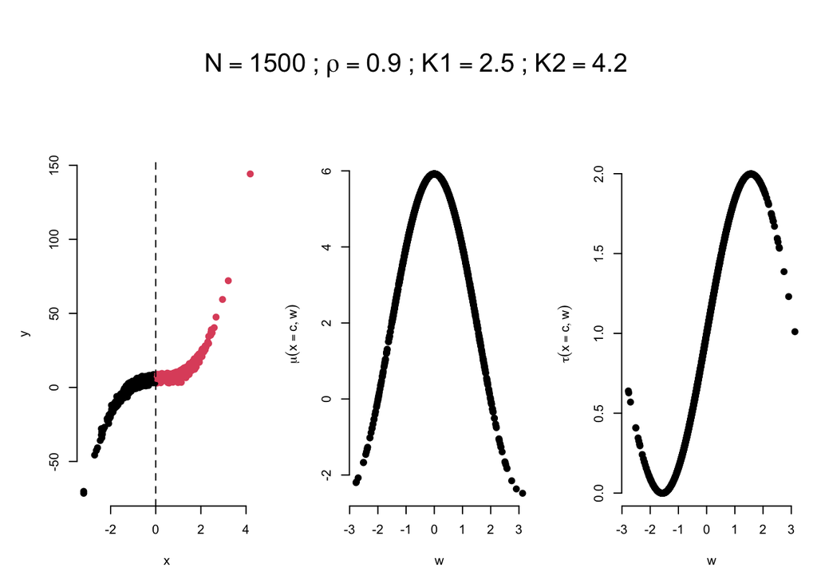

```r
set.seed(7)
### Functions
mu0.x <- function(x,k) -0.03*x^5 + k*0.5*x^3 + 0.1*x^2 - 0.1*x + 1.72
mu0.w <- function(w,k) k*1.4*cos(w)
tau0.x <- function(x,c) 1/(1-exp(-4-x)) - 1.02
tau0.w <- function(w) sin(w)
mu <- function(x,w,k1,k2) mu0.x(x,k1) + mu0.w(w,k2)
tau <- function(x,c,w,ate) tau0.x(x,c) + tau0.w(w) + ate
h.grid <- function(x,c,grid)
{
  abs.x <- sort(abs(x-c))
  out <- rep(0,length(grid))
  names(out) <- grid
  x.right <- sum(c < x)
  x.left <- sum(x < c)
  x.tot <- length(x)
  for(total in grid)
  {
    i <- 1
    sum.right <- sum.left <- 0
    while(sum.right < total | sum.left < total)
    {
      sum.left <- sum(c-abs.x[i] <= x & x < c)
      sum.right <- sum(c < x & x <= c+abs.x[i])
      if (sum.left == sum(x<c) & sum.right == sum(c<x)) break
      i <- i+1
    }
    out[as.character(total)] <- abs.x[i]
  }
  return(out)
}
## Parameters
n <- 1500
rho <- c(0.5,0.9)
k1 <- c(1,5)
k2 <- c(1,3)
pts_in_window <- 75
sig_error <- 1
c <- 0
ate <- 1
for (Rho in rho)
{
  for (K1 in k1)
  {
    for (K2 in k2)
    {
      ## Generate data
      x <- rnorm(n)
      h <- h.grid(x,c,pts_in_window)
      test <- -h<x & x<h
      z <- as.numeric(x>=c)
      w <- rnorm(n,Rho*x,sqrt(1-Rho^2))
      cate <- tau(c,c,w,ate)
      prog <- mu(c,w,K1,K2)
      Ey <- mu(x,w,K1,K2) + tau(x,c,w,ate)*z
      y <- Ey + rnorm(n,0,sqrt(sig_error))
      title <- bquote(N==.(n)
                      ~";"~rho==.(Rho)
                      ~";"~K1==.(K1*0.5)
                      ~";"~K2==.(K2*1.4))
      ## Plot data
      par(bty="n",pch=19)
      layout(matrix(c(1,2,1,3,1,4),ncol=3),height=c(1,3))
      par(mar=c(2,2,1,1))
      plot.new()
      text(0.5,0.5,title,cex=2,font=2)
      ###
      par(mar=c(5,5,1,1))
      plot(x,y,col=z+1)
      abline(v=c,lty=2)
      ###
      plot(w,prog,ylab=bquote(mu(x==c,w)))
      ###
      plot(w,cate,ylab=bquote(tau(x==c,w)))
    }
  }
}
```